# ADP04

#### 산점도

- main : 제목
- xlab / ylab : 축 이름
- xlim / ylim : 좌표축 범위
- pch : 점의 종류 (0 ~ 18 : S언어 / 19 ~ 25 : 특수문자 / 32 ~ 127 : 아스키코드 )
- cex : 점의 크기
- col : 점의 색상
- type : 그래프 종류 (p : 점 / l : 선 / b : 점과 선을 연결 / o : 점과 선을 중첩 / n : 그래프 초기화)
- lty : 선 종류 (0 : 그리지 않음 / 1 : 실선 / 2 : 대시(-) / 3 : 점 / 4 : 점과 대시 / 5 : 긴 대시 / 6 : 두 개의 대시)
- lwd : 선 굵기

```r
library(MASS)
```

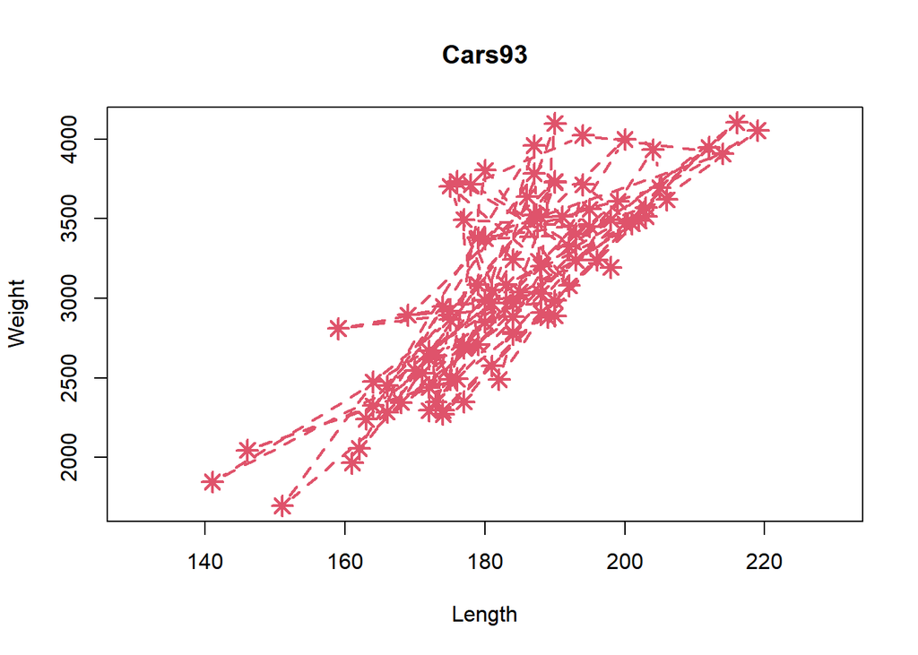

```r
plot(Cars93$Length, Cars93$Weight,
     main = "Cars93", # 제목
     xlab = "Length", ylab = "Weight", # 축 이름
     xlim = c(130, 230), ylim = c(1695, 4105), # 좌표축 범위
     pch = 8,
     # 점의 종류
     cex = 1.5, # 점의 크기
     col = 50, # 점의 색상
     type = "b", # 그래프 종류
     lty = 2, # 선 종류
     lwd = 2 # 선 굵기
     )
```

###### - 범례 - 위치 : “bottom”, “top”, “right”, “left”, “center”, 좌표 - pch : 점 그래프 범례 표시 형식 지정 - lty : 선 그래프 범례 표시 형식 지정 - fill : 면 그래프 범례 표시 형식 지정 - title : 범례 제목 지정 - bg : 범례의 배경 색 지정

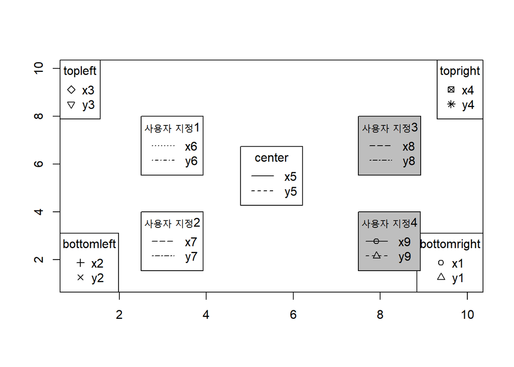

```r
plot(1:10, type="n", xlab=" ", ylab=" ")

legend("bottomright", c("x1","y1"), pch=1:2, title="bottomright")
legend("bottomleft", c("x2","y2"), pch=3:4, title="bottomleft")
legend("topleft", c("x3","y3"), pch=5:6, title="topleft")
legend("topright", c("x4","y4"), pch=7:8, title="topright")
legend("center", c("x5","y5"), lty=1:2, title="center")

legend(2.5,8,c("x6","y6"),lty=3:4,title="사용자 지정1")
legend(2.5,4,c("x7","y7"),lty=5:6,title="사용자 지정2")
legend(7.5,8,c("x8","y8"),lty=5:6,bg="gray",title="사용자 지정3")
legend(7.5,4,c("x9","y9"),
       pch=1:2,
       lty=7:8,
       bg="gray",
       title="사용자 지정4")
```

#### 그래프

- 점 그래프

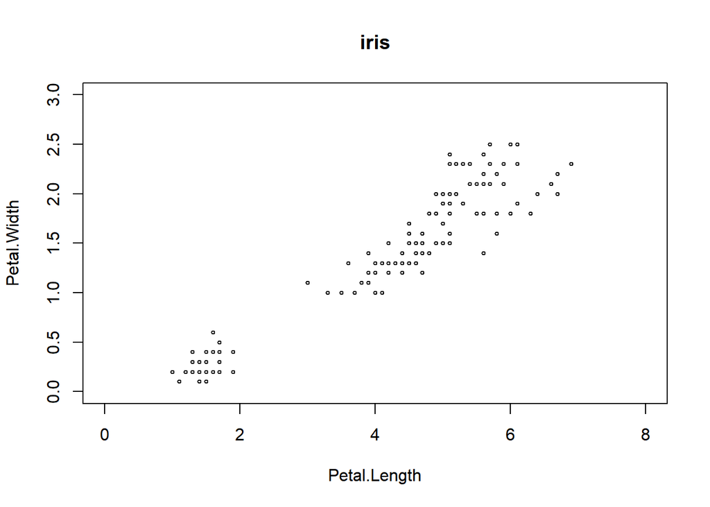

```r
plot(NULL, type="n",xlim=c(0,8), ylim=c(0,3), xlab="Petal.Length", ylab="Petal.Width", main="iris")
points(iris$Petal.Length, iris$Petal.Width, cex=0.5)
```

- 꺾은선 그래프

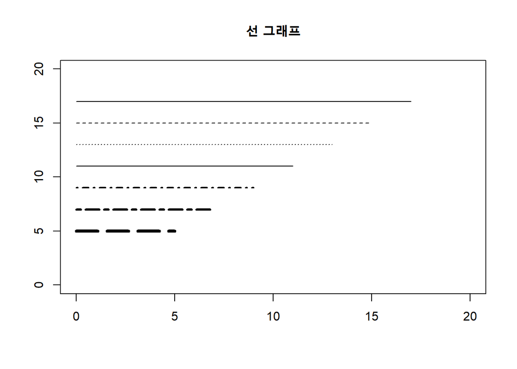

```r
plot(NULL, type="n", xlab="", ylab="", xlim=c(0,20), ylim=c(0,20), main="선 그래프")
lines(c(0,17), c(17,17), lty=1)
lines(c(0,15), c(15,15), lty=2)
lines(c(0,13), c(13,13), lty=3)
lines(c(0,11), c(11,11), lty="solid", lwd=1)
lines(c(0,9), c(9,9), lty="dotdash", lwd=2)
lines(c(0,7), c(7,7), lty="twodash", lwd=3)
lines(c(0,5), c(5,5), lty="longdash", lwd=4)
```

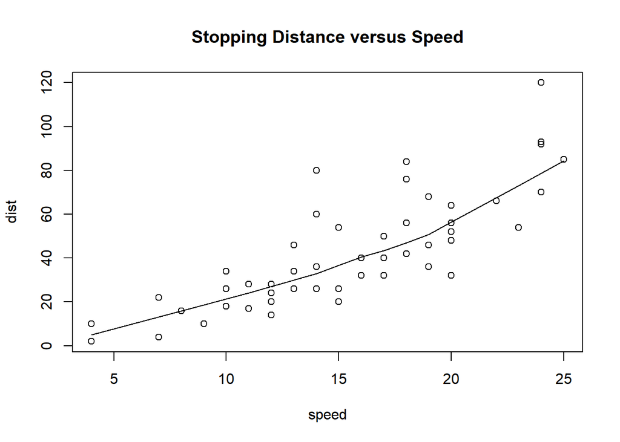

```r
plot(cars, main = "Stopping Distance versus Speed")
lines(lowess(cars))
```

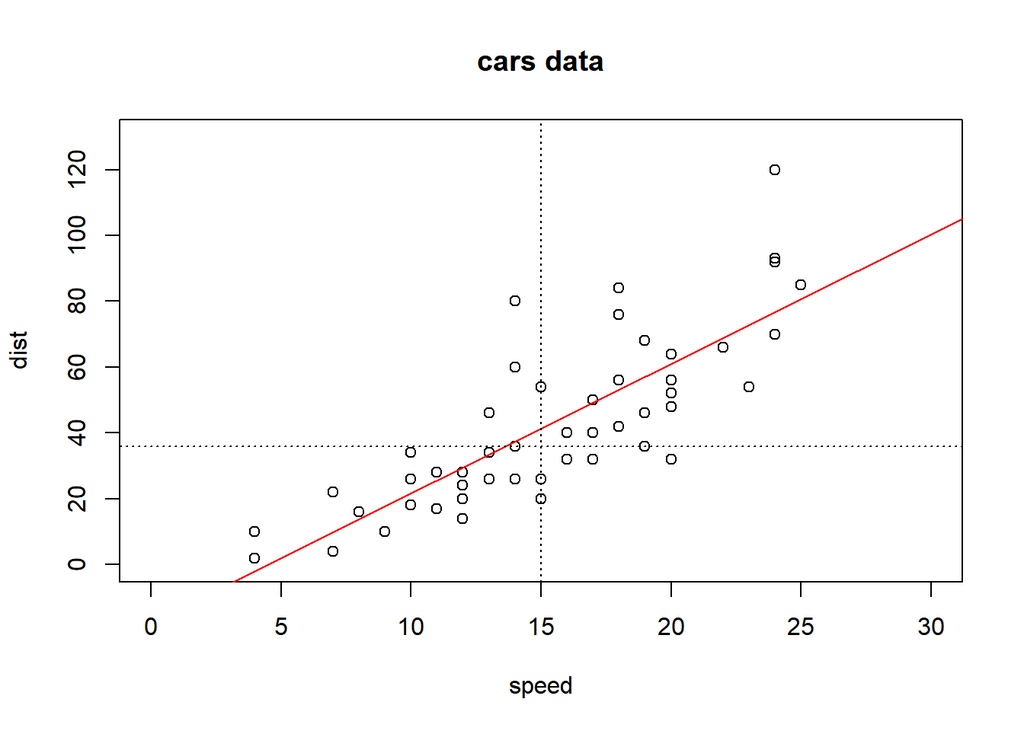

```r
plot(cars, ylim=c(0,130), xlim=c(0,30), main="cars data")
cars_lm<-lm(dist~speed, data=cars)
abline(cars_lm, col="red")

abline(v = median(cars$speed), lty=3)
abline(h = median(cars$dist), lty=3)
```

- 곡선 그래프 curve(expr, from = …, to = … ) - expr : 그래프 표현할 식 - from : x축 시작점 - to : x축 끝점

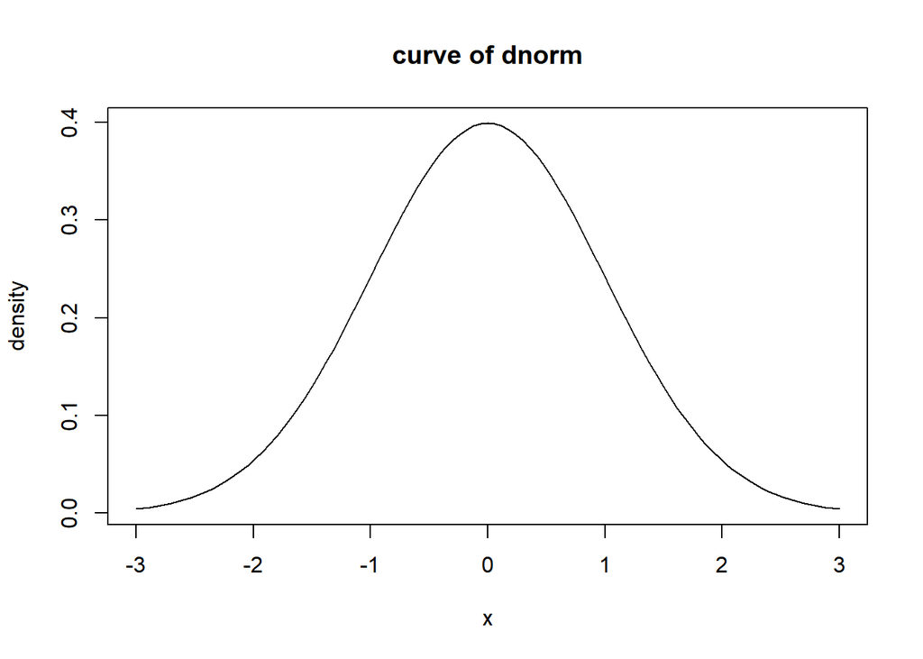

```r
curve(dnorm(x, mean=0, sd=1),
      from=-3, to=3,
      xlab="x", ylab="density", main="curve of dnorm")
```

- 막대 그래프 barplot(height, names.arg, space, horiz, main, xlab, ylab, col, beside, xlim, ylim) - beside : 범주가 여러 개일 경우의 표현 (TRUE : 여러 범주를 병렬로 / FALSE : 누적 막대)

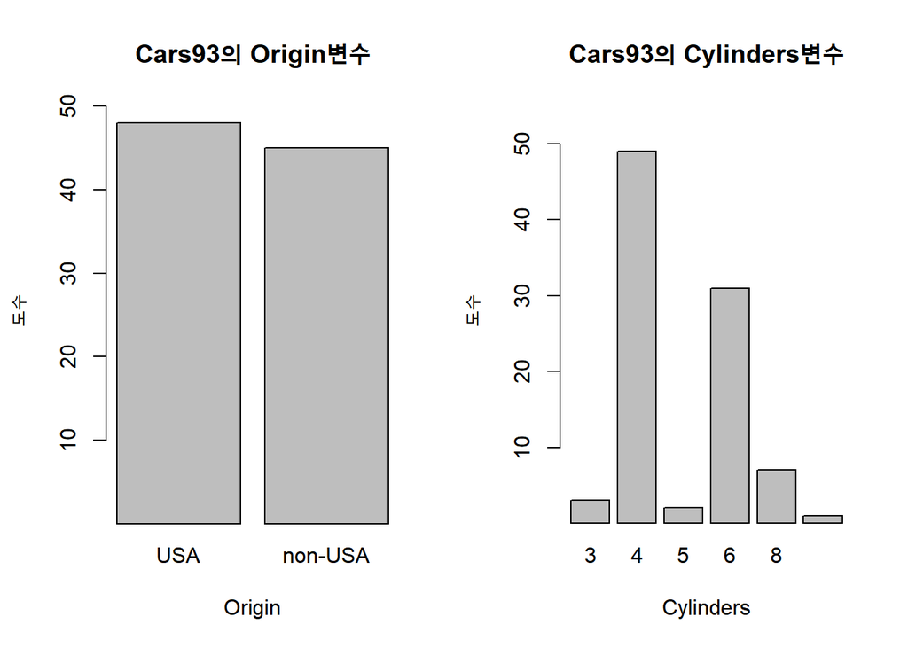

```r
par(mfrow = c(1,2))
barplot(table(Cars93$Origin), ylim=c(1,50), xlab="Origin", ylab="도수",
        main="Cars93의 Origin변수")

barplot(table(Cars93$Cylinders), ylim=c(1,55), xlab="Cylinders", ylab="도수",
        main="Cars93의 Cylinders변수")
```

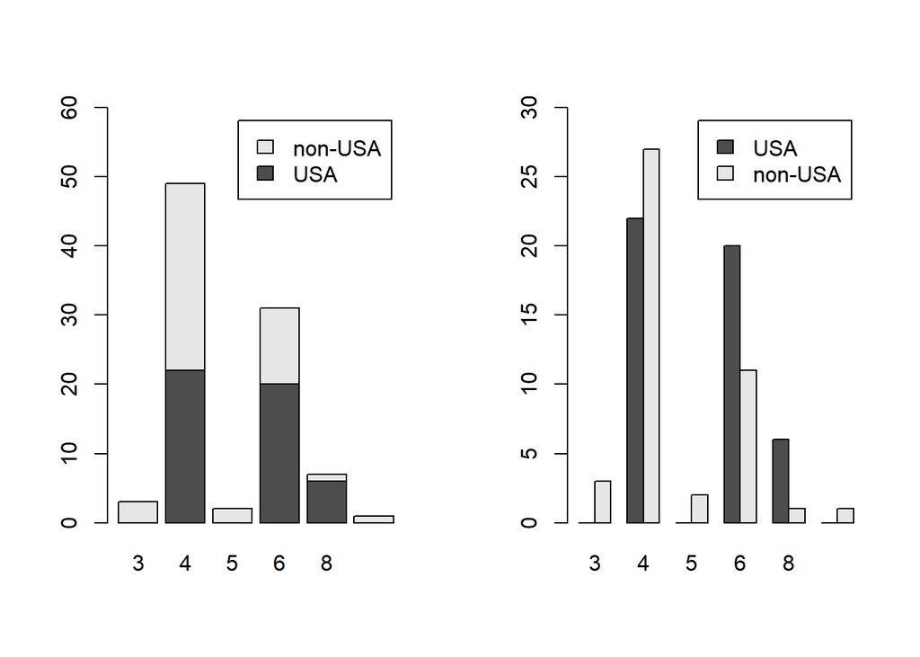

```r
par(mfrow = c(1,2))
barplot(table(Cars93$Origin,Cars93$Cylinders), beside=F, ylim=c(0,60), legend=T)

barplot(table(Cars93$Origin,Cars93$Cylinders), beside=T, ylim=c(0,30), legend=T)
```

- 히스토그램 hist(x, main, xlab, ylab, breaks, freq, col) - breaks : 막대의 구간 - freq : y축에 구간별 데이터의 개수(빈도)를 표시할지의 여부 (값을 지정하지 않거나 TRUE로 지정할 경우 : y축에 빈도가 표시 / FALSE : y축에 구간별 데이터의 확률밀도)

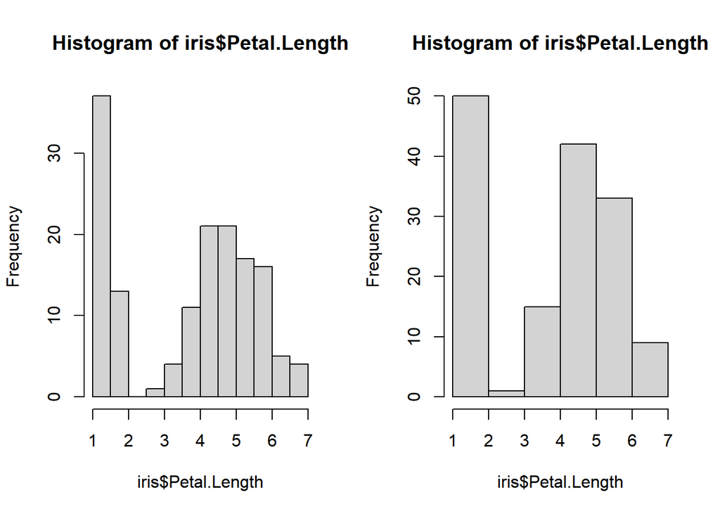

```r
par(mfrow = c(1,2))
hist(iris$Petal.Length)
hist(iris$Petal.Length, breaks=5)
```

- 파이 차트

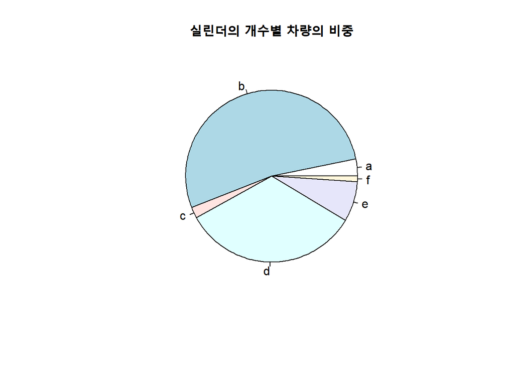

```r
pie(table(Cars93$Cylinders),
    labels = c("a","b","c","d","e","f"), # 파이차트 각 부분의 이름
    main="실린더의 개수별 차량의 비중")
```

- 산점도 행렬

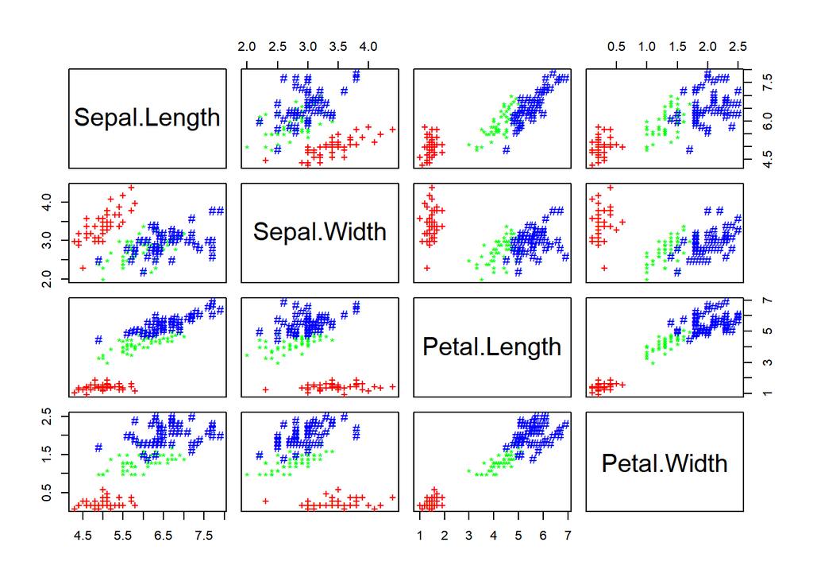

```r
pairs( ~Sepal.Length + Sepal.Width + Petal.Length + Petal.Width,
       data=iris,
       col=c("red","green","blue")[iris$Species],
       # Species별로 색을 다르게
       pch=c("+","*","#")[iris$Species]) # Species별로 모양을 다르게
```